# 予測問題: 発展

機械学習

[川田恵介](https://github.com/tetokawata/TargetML)

keisukekawata@iss.u-tokyo.ac.jp

東京大学

2025-11-11

# 今後の予定

## ここまで

- OLS/LASSO (線型モデル) を用いた
  - 予測分析: $X$ (物件の属性) の情報から $Y$ (取引価格) を推測するモデルを推定
  - 比較分析: 同じような $X$ を持つ物件について、$D$ (改築済み/未改築) と $Y$ (取引価格) の関係性を推定

## 課題

- 線型モデルを当てはめることが難しい母集団も存在
  - 予測精度の悪化、ミスリードな推定結果
- $Y$ と $D$ の関係性は、$X$に依存
- より柔軟なアプローチが必要

## 実例

```r
library(tidyverse)

data <- read_csv("Public/example.csv")

Y <- data$Price

D <- data$year_2024

X <- model.matrix(
  ~ 0 + Tenure + RoomNumber,
  data
)
```

## 実例: 予測モデル推定

```r
model_Y <- ranger::ranger(
  y = Y,
  x = X
) # Random Forest
```

## 実例: 価格予測モデル

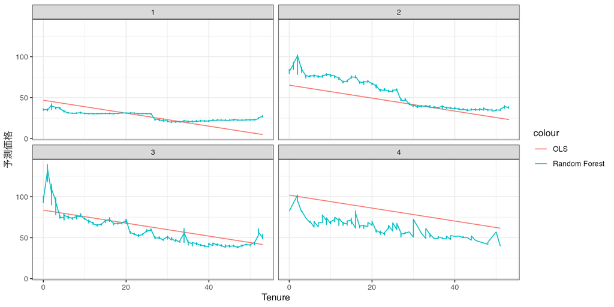

## 実例: 2024 VS 2021

```r
model_Tau <- grf::causal_forest(
  X = X,
  Y = Y,
  W = D
) # Causal Forest
```

## 実例: 2024 VS 2021

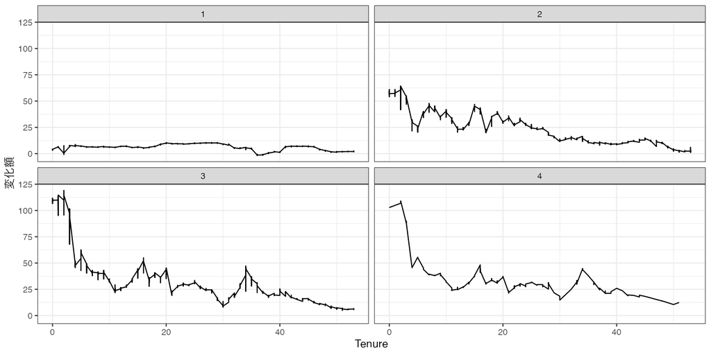

## RoadMap

- 線型モデルを補うために、回帰木モデルを改善する
  - Random Forest
- LASSO以外も活用できる柔軟な比較分析の方法を紹介
  - Double/debiased machine learning

# 回帰木モデルの利点と弱点

## 回帰木モデルの復習

- サブグループの平均値を予測値とする
  - サブグループは、データへの当てはまりを改善するように決定する

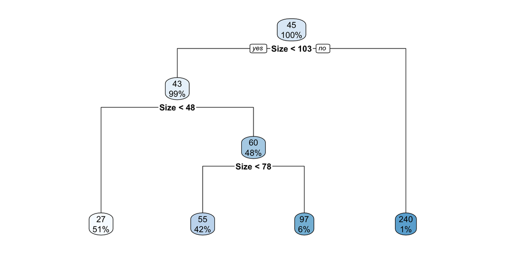

```r
model <- rpart::rpart(Price ~ Size, data)

rpart.plot::rpart.plot(model)
```

## 線型 VS 回帰木

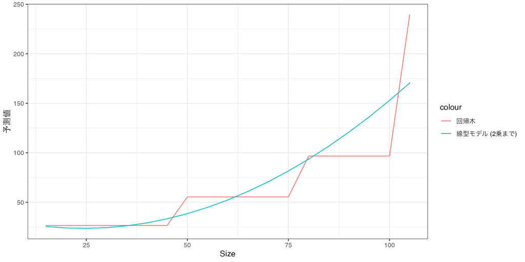

## 回帰木の利点

- 線型モデルに比べて、$Y$ の母平均が”急変”する母集団に当てはめることが容易

## 例: $Y\sim X$

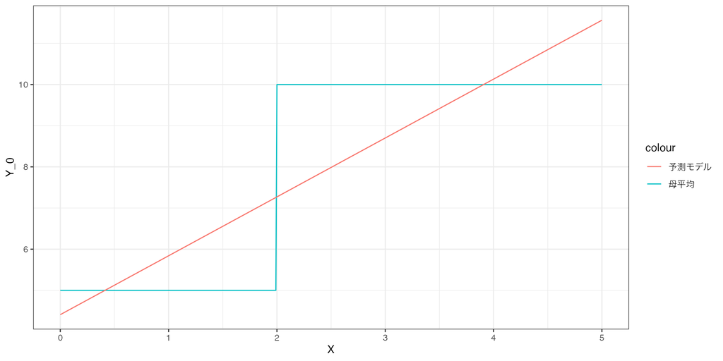

## 例: $Y\sim X + X^2 +..+ X^6$

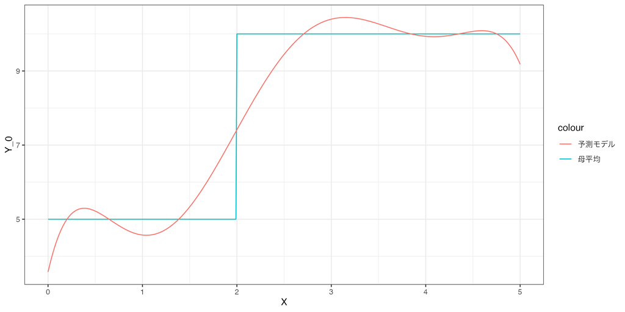

## 例: 回帰木

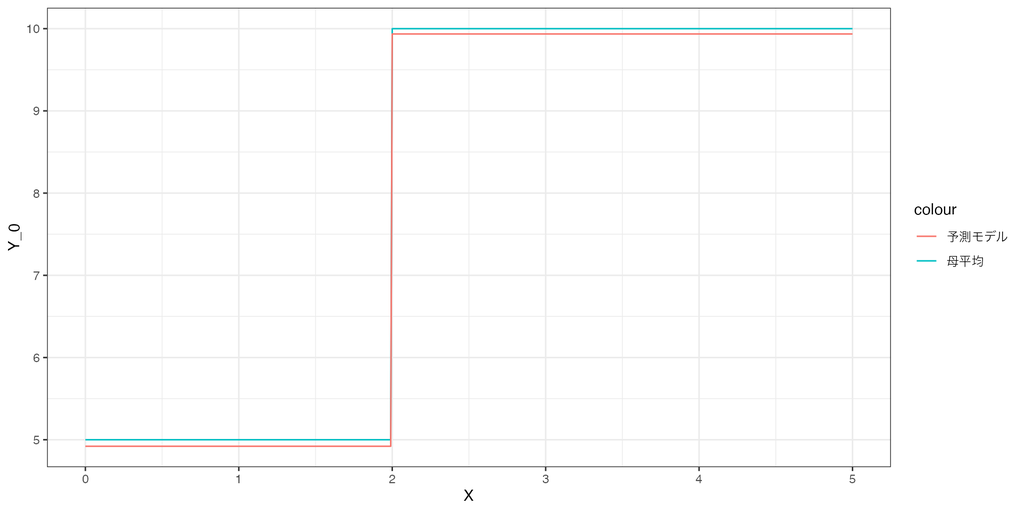

## 弱点

- データからの推定結果は、データの偏りの影響を受ける
  - ハズレ値の影響を受ける
- OLSやLASSOに比べて、回帰木はハズレ値の影響を受けやすい
  - モデル集計により解決できる

# モデル集計

## 集計による解決

- データへの、平均値から極端に乖離した事例やその組み合わせの”混入”は、推定結果に大きな影響を与える
- モデルの単純化も選択肢だが、回帰木については不十分な場合が多い

## 数値例 (200事例)

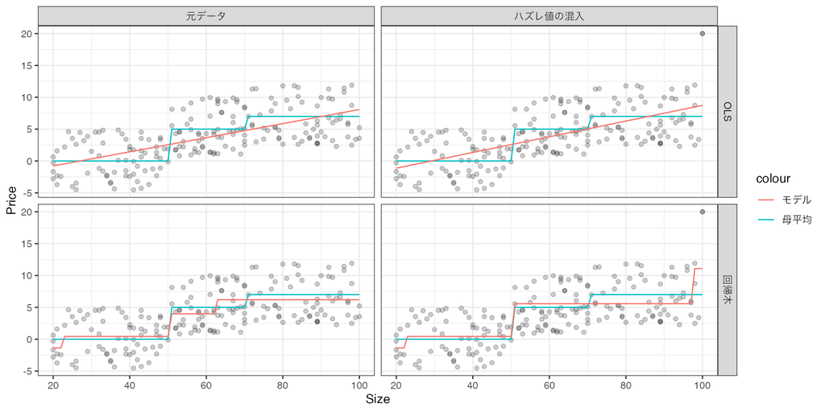

## 解決策

- 伝統的なアプローチ: “ハズレ値”を人間が除外
  - 採用するのであれば、“細心の注意”が必要
  - (議論はあるが)、極力避けた方が良い

## 集計による解決

- モデルの集計
  - “異なる”データを用いた予測モデルの集計値(平均値)を最終予測とする
    - 特定のハズレ値の影響を緩和できる
- 問題点: 通常、データは一つしかない
  - 対応策: Boostrap法により、データを複製する

## シンプルな例

- データ $=[5,6,100]$
- 復元抽出により、同じ数(3)の事例をランダムに選ぶ
  - 複製データ1 $=[6,6,100]=$ の平均値 37.3
  - 複製データ2 $=[6,6,5]=$ の平均値 5.7
  - 複製データ3 $=[5,5,5]=$ の平均値 5
- 最終予測 $=$ 16
- ハズレ値(“100”)を反映しない予測も活用される

## 数値例

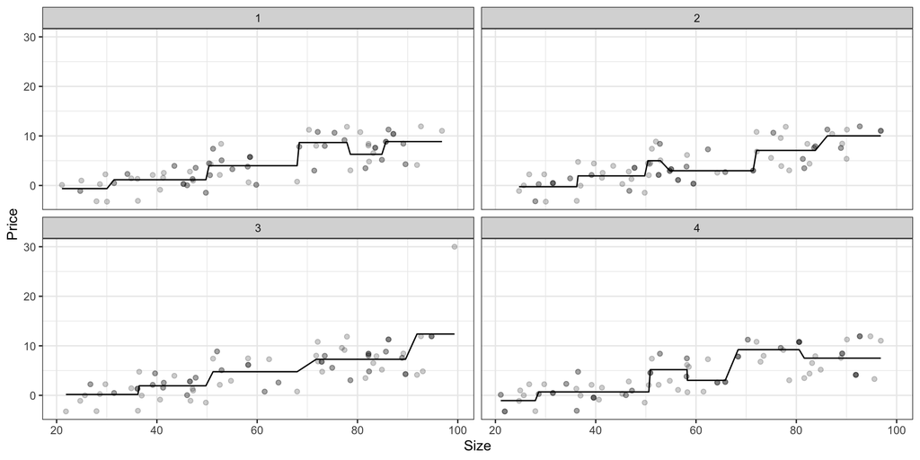

# モデル集計: 発展

## 予測モデルの選択

- OLSやRandom Forest等で推定した予測値のうち、どれを使用するのか?
  - 理論的に常に優れた方法は存在しない
- 方法1. 予測性能を評価し、最善のモデルを利用する
- 方法2. 予測値を集計

## モデルの集計 (Stacking)

- 最終予測モデル
  $$=\beta_{OLS}\times OLSの予測$$
  $$+ \beta_{RF}\times RandomForestの予測 + ...$$
  - $\beta:$ 各予測結果を反映させる度合い
  - 各予測値を”X”として用いた、線型モデル

## 推定方法

1. データをサブデータ $\{1,..,G\}$ にランダム分割
2. 第1サブデータ**以外**で予測モデルを推定し、第1サブデータを予測
3. 第2サブデータ**以外**で予測モデルを複数推定し、第2サブデータを予測
4. 以上を全てのデータについて繰り返す
5. 予測対象 $Y$ に対して、各予測値で回帰して $\beta$ を推定

## 数値例: 3分割

```
# A tibble: 9 × 3
  StationDistance    Price Group
            <int>    <dbl> <fct>
1               9  6.05    3
2               4  3.94    2
3               7 31.0     3
4               1  8.64    1
5               2 -5.99    3
6               7 -4.48    1
7               2 -0.895   1
8               3  0.00785 2
9               1 -3.12    2
```

## 数値例: Step 1

```
# A tibble: 9 × 5
  StationDistance    Price Group   OLS RandomForest
            <int>    <dbl> <fct> <dbl>        <dbl>
1               9  6.05    3     NA           NA
2               4  3.94    2     NA           NA
3               7 31.0     3     NA           NA
4               1  8.64    1     -4.12        -1.89
5               2 -5.99    3     NA           NA
6               7 -4.48    1     12.9         16.7
7               2 -0.895   1     -1.29        -1.91
8               3  0.00785 2     NA           NA
9               1 -3.12    2     NA           NA
```

- Group 2,3をTrainingデータとして活用

## 数値例: Step 2

```
# A tibble: 9 × 5
  StationDistance    Price Group    OLS RandomForest
            <int>    <dbl> <fct>  <dbl>        <dbl>
1               9  6.05    3     NA           NA
2               4  3.94    2      4.86        -0.189
3               7 31.0     3     NA           NA
4               1  8.64    1     -4.12        -1.89
5               2 -5.99    3     NA           NA
6               7 -4.48    1     12.9         16.7
7               2 -0.895   1     -1.29        -1.91
8               3  0.00785 2      3.55        -0.189
9               1 -3.12    2      0.938        1.91
```

- Group 1,3をTrainingデータとして活用

## 数値例: Step 3

```
# A tibble: 9 × 5
  StationDistance    Price Group    OLS RandomForest
            <int>    <dbl> <fct>  <dbl>        <dbl>
1               9  6.05    3     -4.88        -1.84
2               4  3.94    2      4.86        -0.189
3               7 31.0     3     -3.03        -1.84
4               1  8.64    1     -4.12        -1.89
5               2 -5.99    3      1.61         0.945
6               7 -4.48    1     12.9         16.7
7               2 -0.895   1     -1.29        -1.91
8               3  0.00785 2      3.55        -0.189
9               1 -3.12    2      0.938        1.91
```

- Group 1,2をTrainingデータとして活用

## 数値例: Stacking

```r
lm(Price ~ OLS + RandomForest, PopData)
```

```
Call:
lm(formula = Price ~ OLS + RandomForest, data = PopData)

Coefficients:
 (Intercept)           OLS  RandomForest
       5.056        -1.248         0.243
```

- $\omega$ を非負、総和を1に基準化することも有効

## まとめ

- 伝統的な推定手法ではあまり用いられてこなかった、アイディアを用いた多くの手法が存在
- PCの処理能力の向上により、現実的な手法となる
- 常に上手くいく方法は現状存在しないので、複数の推定値の集計値を用いる方法を推奨
- 継続学習用推奨資料: [An Introduction to Statistical Learning](https://www.statlearning.com/)